# lab7 Assignment

Somnath Mukherjee

March 16, 2019

### Lab set-up

```r
#read input file
RENTS=read.table(here('lab7','data',"data7.txt"), header = TRUE, sep = "", dec = ".")
RENTS=RENTS[,-1] # Removes the column with the observation number.
RENTS[,c(1:4,9)] = lapply(RENTS[,c(1:4,9)], as.numeric) # Makes sure that all numeric variables are seen as such by R
RENTS[,5:8] = lapply(RENTS[,5:8], as.factor) # Makes sure that all factor variables are seen as such by R
```

### 1. Run all three of the selection methods discussed above. Report the result of each method.

First we will fit the full model, so that it will be easy to compare the reduced models later for their merits.

```r
#' fit the full model for MLR
full.model <- lm(rent ~., data = RENTS)
summary(full.model)
```

```
##
## Call:
## lm(formula = rent ~ ., data = RENTS)
##
## Residuals:
##    Min     1Q Median     3Q    Max
## -73.84 -14.44   2.63  15.74  86.42
##
## Coefficients:
##              Estimate Std. Error t value Pr(>|t|)
## (Intercept) 104.90554   85.34863   1.229  0.23046
## age          -6.68209    2.12724  -3.141  0.00429 **
## sqft          0.63610    0.11585   5.491 1.05e-05 ***
## sd           -0.40282    0.24945  -1.615  0.11889
## unts          0.09790    0.06011   1.629  0.11593
## gar1         64.99759   18.23188   3.565  0.00150 **
## cp1          33.05119   15.75202   2.098  0.04615 *
## ss1          -9.97656   15.21852  -0.656  0.51810
## fit1         14.32711   15.11650   0.948  0.35231
## ---
## Signif. codes:  0 '***' 0.001 '**' 0.01 '*' 0.05 '.' 0.1 ' ' 1
##
## Residual standard error: 35.54 on 25 degrees of freedom
## Multiple R-squared:  0.7824, Adjusted R-squared:  0.7128
## F-statistic: 11.24 on 8 and 25 DF,  p-value: 1.353e-06
```

As can be seen from the table above, the model is significant based on the F-statistic p-value.  
Hence we have a regression effect and at least one of the beta coefficient (partial regression coefficient) is significant.  
Results with significant variables based on t-test p-values are marked with astericks at different significance level. Not all variables are significant (e.g. ss1,fit1) though.  
For the full model:

```r
an1=anova(full.model) # Traditional Analysis of variance
SS1=an1$`Sum Sq`# List of Sums of Squares Type I
SS1
```

```
## [1] 20999.7531 35364.0585  5960.6873  8678.1884 33364.2403  7640.9080
## [7]   418.8718  1134.6329 31577.7184
```

```r
an1
```

```
## Analysis of Variance Table
##
## Response: rent
##           Df Sum Sq Mean Sq F value    Pr(>F)
## age        1  21000   21000 16.6255  0.000406 ***
## sqft       1  35364   35364 27.9976 1.757e-05 ***
## sd         1   5961    5961  4.7191  0.039517 *
## unts       1   8678    8678  6.8705  0.014697 *
## gar        1  33364   33364 26.4144 2.599e-05 ***
## cp         1   7641    7641  6.0493  0.021176 *
## ss         1    419     419  0.3316  0.569855
## fit        1   1135    1135  0.8983  0.352314
## Residuals 25  31578    1263
## ---
## Signif. codes:  0 '***' 0.001 '**' 0.01 '*' 0.05 '.' 0.1 ' ' 1
```

**Fitting backward selection model:**

```r
stepback.model <- stepAIC(full.model, direction = "backward",trace = FALSE)
summary(stepback.model)
```

```
##
## Call:
## lm(formula = rent ~ age + sqft + sd + unts + gar + cp, data = RENTS)
##
## Residuals:
##     Min      1Q  Median      3Q     Max
## -68.278 -15.847   1.405  22.173  90.904
##
## Coefficients:
##              Estimate Std. Error t value Pr(>|t|)
## (Intercept) 110.31636   83.72741   1.318 0.198721
## age          -6.46376    2.08408  -3.101 0.004474 **
## sqft          0.61299    0.11230   5.458 8.91e-06 ***
## sd           -0.34022    0.23759  -1.432 0.163637
## unts          0.10693    0.05751   1.859 0.073903 .
## gar1         66.97266   16.50823   4.057 0.000381 ***
## cp1          37.46669   15.01446   2.495 0.018993 *
## ---
## Signif. codes:  0 '***' 0.001 '**' 0.01 '*' 0.05 '.' 0.1 ' ' 1
##
## Residual standard error: 35.03 on 27 degrees of freedom
## Multiple R-squared:  0.7717, Adjusted R-squared:  0.721
## F-statistic: 15.21 on 6 and 27 DF,  p-value: 1.522e-07
```

As can be seen from the table above, the model is significant based on the F-statistic p-value.  
Hence we have a regression effect and at least one of the beta coefficient (partial regression coefficient) is significant.  
Results with significant variables based on t-test p-values are marked with astericks at different significance level.  
Two variables (ss1 and fit1) got removed from the full model.

For the backward selection:

```r
an2=anova(stepback.model) # Traditional Analysis of variance
SS2=an2$`Sum Sq`# List of Sums of Squares Type I
SS2
```

```
## [1] 20999.753 35364.058  5960.687  8678.188 33364.240  7640.908 33131.223
```

```r
an2
```

```
## Analysis of Variance Table
##
## Response: rent
##           Df Sum Sq Mean Sq F value    Pr(>F)
## age        1  21000   21000 17.1136 0.0003079 ***
## sqft       1  35364   35364 28.8196 1.134e-05 ***
## sd         1   5961    5961  4.8576 0.0362339 *
## unts       1   8678    8678  7.0722 0.0130049 *
## gar        1  33364   33364 27.1899 1.713e-05 ***
## cp         1   7641    7641  6.2269 0.0189934 *
## Residuals 27  33131    1227
## ---
## Signif. codes:  0 '***' 0.001 '**' 0.01 '*' 0.05 '.' 0.1 ' ' 1
```

**Fitting forward selection model:**

```r
stepfor.model <- stepAIC(full.model, direction = "forward",trace = FALSE)
summary(stepfor.model)
```

```
##
## Call:
## lm(formula = rent ~ age + sqft + sd + unts + gar + cp + ss +
##     fit, data = RENTS)
##
## Residuals:
##    Min     1Q Median     3Q    Max
## -73.84 -14.44   2.63  15.74  86.42
##
## Coefficients:
##              Estimate Std. Error t value Pr(>|t|)
## (Intercept) 104.90554   85.34863   1.229  0.23046
## age          -6.68209    2.12724  -3.141  0.00429 **
## sqft          0.63610    0.11585   5.491 1.05e-05 ***
## sd           -0.40282    0.24945  -1.615  0.11889
## unts          0.09790    0.06011   1.629  0.11593
## gar1         64.99759   18.23188   3.565  0.00150 **
## cp1          33.05119   15.75202   2.098  0.04615 *
## ss1          -9.97656   15.21852  -0.656  0.51810
## fit1         14.32711   15.11650   0.948  0.35231
## ---
## Signif. codes:  0 '***' 0.001 '**' 0.01 '*' 0.05 '.' 0.1 ' ' 1
##
## Residual standard error: 35.54 on 25 degrees of freedom
## Multiple R-squared:  0.7824, Adjusted R-squared:  0.7128
## F-statistic: 11.24 on 8 and 25 DF,  p-value: 1.353e-06
```

As can be seen from the table above, the model is significant based on the F-statistic p-value.  
Hence we have a regression effect and at least one of the beta coefficient (partial regression coefficient) is significant.  
Results with significant variables based on t-test p-values are marked with astericks at different significance level.  
It is same as the full model.  
For the forward selection:

```r
an3=anova(stepfor.model) # Traditional Analysis of variance
SS3=an3$`Sum Sq`# List of Sums of Squares Type I
SS3
```

```
## [1] 20999.7531 35364.0585  5960.6873  8678.1884 33364.2403  7640.9080
## [7]   418.8718  1134.6329 31577.7184
```

```r
an3
```

```
## Analysis of Variance Table
##
## Response: rent
##           Df Sum Sq Mean Sq F value    Pr(>F)
## age        1  21000   21000 16.6255  0.000406 ***
## sqft       1  35364   35364 27.9976 1.757e-05 ***
## sd         1   5961    5961  4.7191  0.039517 *
## unts       1   8678    8678  6.8705  0.014697 *
## gar        1  33364   33364 26.4144 2.599e-05 ***
## cp         1   7641    7641  6.0493  0.021176 *
## ss         1    419     419  0.3316  0.569855
## fit        1   1135    1135  0.8983  0.352314
## Residuals 25  31578    1263
## ---
## Signif. codes:  0 '***' 0.001 '**' 0.01 '*' 0.05 '.' 0.1 ' ' 1
```

**Fitting stepwise selection model:**

```r
stepboth.model <- stepAIC(full.model, direction = "both",trace = FALSE)
summary(stepboth.model)
```

```
##
## Call:
## lm(formula = rent ~ age + sqft + sd + unts + gar + cp, data = RENTS)
##
## Residuals:
##     Min      1Q  Median      3Q     Max
## -68.278 -15.847   1.405  22.173  90.904
##
## Coefficients:
##              Estimate Std. Error t value Pr(>|t|)
## (Intercept) 110.31636   83.72741   1.318 0.198721
## age          -6.46376    2.08408  -3.101 0.004474 **
## sqft          0.61299    0.11230   5.458 8.91e-06 ***
## sd           -0.34022    0.23759  -1.432 0.163637
## unts          0.10693    0.05751   1.859 0.073903 .
## gar1         66.97266   16.50823   4.057 0.000381 ***
## cp1          37.46669   15.01446   2.495 0.018993 *
## ---
## Signif. codes:  0 '***' 0.001 '**' 0.01 '*' 0.05 '.' 0.1 ' ' 1
##
## Residual standard error: 35.03 on 27 degrees of freedom
## Multiple R-squared:  0.7717, Adjusted R-squared:  0.721
## F-statistic: 15.21 on 6 and 27 DF,  p-value: 1.522e-07
```

As can be seen from the table above, the model is significant based on the F-statistic p-value.  
Hence we have a regression effect and at least one of the beta coefficient (partial regression coefficient) is significant.  
Results with significant variables based on t-test p-values are marked with astericks at different significance level.  
Two variables (ss1 and fit1) got removed from the full model.  
For stepwise:

```r
an4=anova(stepboth.model) # Traditional Analysis of variance
SS4=an4$`Sum Sq`# List of Sums of Squares Type I
SS4
```

```
## [1] 20999.753 35364.058  5960.687  8678.188 33364.240  7640.908 33131.223
```

```r
an4
```

```
## Analysis of Variance Table
##
## Response: rent
##           Df Sum Sq Mean Sq F value    Pr(>F)
## age        1  21000   21000 17.1136 0.0003079 ***
## sqft       1  35364   35364 28.8196 1.134e-05 ***
## sd         1   5961    5961  4.8576 0.0362339 *
## unts       1   8678    8678  7.0722 0.0130049 *
## gar        1  33364   33364 27.1899 1.713e-05 ***
## cp         1   7641    7641  6.2269 0.0189934 *
## Residuals 27  33131    1227
## ---
## Signif. codes:  0 '***' 0.001 '**' 0.01 '*' 0.05 '.' 0.1 ' ' 1
```

### 2. Do you get the same reduced model from three methods? Make brief comments.

We do not have same reduced model from all of the three method. Backward and stepwise selection ends up with same model whereas forward selection yields to full-model.  
Two variables (ss1 and fit1) got removed from the full model, in case of backward and stepwise selection.  
Once a variable enters forward selection model, it can not leave the model even though it might become non-significant at later steps.  
That’s why we usually observe a difference in reduced models adopting different selection techniques.

### 3. Which model do you think is the “best” reduced model? Discuss why you choose this model.

According to me the best model is the reduced model which we arrive from backward(or stepwise) selection.  
Reasons:  
1.stepAIC function in R will provide the reduced model based on optimized AIC value.  
2.For backward selection reduced model, we have better adjusted R-square (0.721) than forward selection (0.712).  
3.In fact, we have a better adjusted R-square with less number of regressor(or variable) for backward selection.  
4.The F-statistics P-value for the reduced model is more significant(1.522e-07 < 1.353e-06) in case of backward selection.

### 4. Use lm to fit the best reduced model. Report the usual results (Hints: hypothesis test results, parameter estimates, validity of assumptions, multicollinearity, outliers, and influential statistics).

Fitting the reduced model:

```r
reduced.model <- lm(rent ~  age + sqft + sd + unts + gar + cp,data = RENTS ) # This is the reduced multilinear regression model.
summary(reduced.model)
```

```
##
## Call:
## lm(formula = rent ~ age + sqft + sd + unts + gar + cp, data = RENTS)
##
## Residuals:
##     Min      1Q  Median      3Q     Max
## -68.278 -15.847   1.405  22.173  90.904
##
## Coefficients:
##              Estimate Std. Error t value Pr(>|t|)
## (Intercept) 110.31636   83.72741   1.318 0.198721
## age          -6.46376    2.08408  -3.101 0.004474 **
## sqft          0.61299    0.11230   5.458 8.91e-06 ***
## sd           -0.34022    0.23759  -1.432 0.163637
## unts          0.10693    0.05751   1.859 0.073903 .
## gar1         66.97266   16.50823   4.057 0.000381 ***
## cp1          37.46669   15.01446   2.495 0.018993 *
## ---
## Signif. codes:  0 '***' 0.001 '**' 0.01 '*' 0.05 '.' 0.1 ' ' 1
##
## Residual standard error: 35.03 on 27 degrees of freedom
## Multiple R-squared:  0.7717, Adjusted R-squared:  0.721
## F-statistic: 15.21 on 6 and 27 DF,  p-value: 1.522e-07
```

As can be seen from the table above, the model is significant based on the F-statistic p-value: 1.522e-07.  
Hence we have a regression effect and at least one of the beta coefficient (partial regression coefficient) is significant.  
Results with significant variables based on t-test p-values are marked with astericks at different significance level.  
All the parameter estimates are listed above in the table.

**Test for multicollinearity**

```r
ols_coll_diag(reduced.model) # Collinearity diagnostics table
```

```
## Tolerance and Variance Inflation Factor
## ---------------------------------------
## # A tibble: 6 x 3
##   Variables Tolerance   VIF
##   <chr>         <dbl> <dbl>
## 1 age           0.901  1.11
## 2 sqft          0.957  1.05
## 3 sd            0.921  1.09
## 4 unts          0.965  1.04
## 5 gar1          0.810  1.23
## 6 cp1           0.823  1.22
##
##
## Eigenvalue and Condition Index
## ------------------------------
##    Eigenvalue Condition Index    intercept          age         sqft
## 1 5.267052835        1.000000 1.796540e-04 5.081279e-03 1.883285e-04
## 2 0.968147971        2.332453 9.732113e-05 1.279010e-02 1.054771e-04
## 3 0.497244216        3.254610 2.660856e-05 2.879920e-03 2.131279e-05
## 4 0.159829294        5.740578 3.982270e-04 7.771890e-01 3.686162e-04
## 5 0.078340088        8.199584 2.987330e-03 7.536302e-02 4.097273e-03
## 6 0.026610943       14.068691 4.331446e-02 1.266593e-01 4.862602e-02
## 7 0.002774653       43.569192 9.529964e-01 3.743591e-05 9.465930e-01
##             sd         unts        gar1          cp1
## 1 1.506837e-03 3.352781e-03 0.006886097 0.0083474932
## 2 1.251387e-03 8.466280e-04 0.345251142 0.2105706813
## 3 9.954419e-04 7.942499e-05 0.507112701 0.7101451695
## 4 1.759925e-02 1.079340e-01 0.123999269 0.0008258601
## 5 1.266845e-01 8.244680e-01 0.007399811 0.0371369059
## 6 8.519584e-01 4.793868e-02 0.005676944 0.0302682174
## 7 4.253110e-06 1.538048e-02 0.003674036 0.0027056726
```

Based on the COndition index value of 43 >30, we still have issue of multicollinearity in the reduced model.

**outliers, and influential statistics**

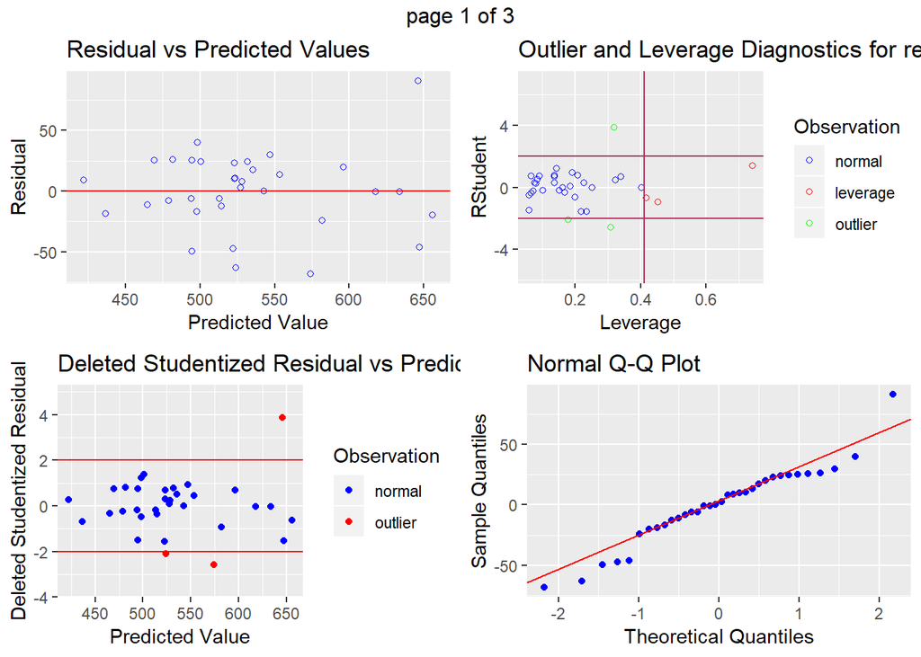

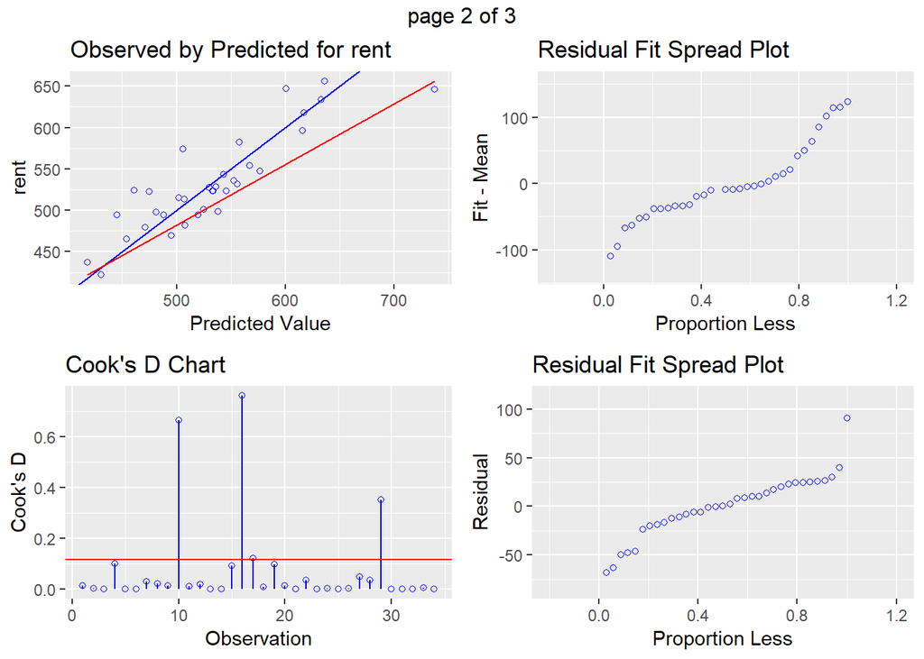

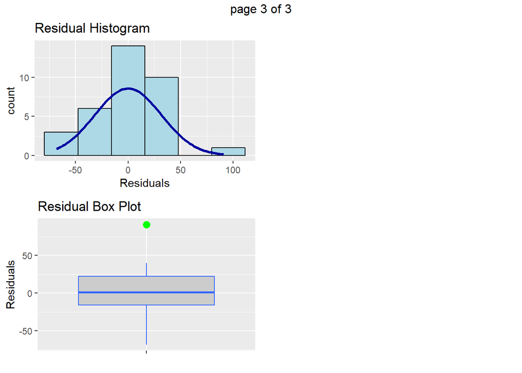

```r
ols_plot_diagnostics(reduced.model) # A panel of plots for regression diagnostics
```

```r
influence.measures(reduced.model)
```

```
## Influence measures of
##   lm(formula = rent ~ age + sqft + sd + unts + gar + cp, data = RENTS) :
##
##       dfb.1_   dfb.age  dfb.sqft   dfb.sd  dfb.unts  dfb.gar1   dfb.cp1
## 1   0.033040  5.97e-02 -0.123195  0.18938  0.139634 -0.045475 -0.044563
## 2  -0.047981 -4.54e-04  0.079139 -0.08062  0.038060 -0.022864 -0.063387
## 3   0.018910 -1.75e-02 -0.014551 -0.04321  0.044195  0.004649  0.002765
## 4   0.392257 -4.36e-01 -0.275048  0.09341 -0.441122  0.121452 -0.303790
## 5  -0.040694 -5.17e-03  0.027281  0.02395  0.012117  0.011865  0.019887
## 6  -0.041284 -7.52e-03  0.014717  0.05829 -0.002661  0.023659  0.048084
## 7   0.103491 -1.24e-01 -0.030105 -0.04619 -0.163331 -0.232046  0.364553
## 8   0.141167 -2.58e-02 -0.152398 -0.02808  0.120734 -0.186504  0.272233
## 9   0.053056  3.59e-02 -0.061348  0.06309 -0.080248 -0.163742 -0.098194
## 10 -1.004040 -2.80e-01  1.269359 -0.93165  0.804348  1.795581 -1.413500
## 11 -0.163506  6.17e-02  0.136239  0.14014 -0.062686 -0.017129 -0.032120
```

[output cut: 58 more lines]

**validity of assumptions: Normality & Homogeneity of variance**

```r
ols_test_normality(reduced.model)
```

```
## -----------------------------------------------
##        Test             Statistic       pvalue
## -----------------------------------------------
## Shapiro-Wilk              0.9498         0.1211
## Kolmogorov-Smirnov        0.1164         0.7033
## Cramer-von Mises          2.7563         0.0000
## Anderson-Darling          0.6038         0.1076
## -----------------------------------------------
```

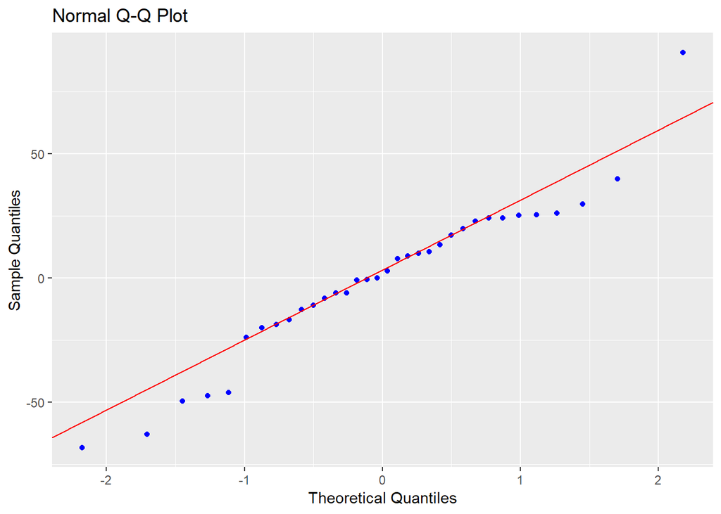

```r
ols_plot_resid_qq(reduced.model)
```

Based on the SW test p-value of 0.12 we can assume normality condition is preserved.

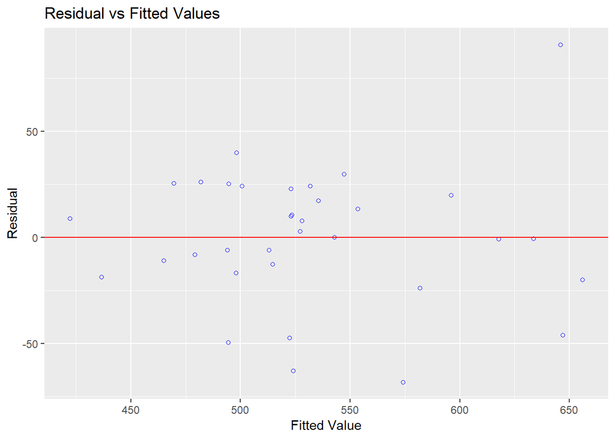

```r
ols_plot_resid_fit(reduced.model)
```

Based on the residual plot above, it seems like a somewhat fan out shape and we can not probably assume homogeneity of variance.